# Advanced Pandas Operations

In this notebook we review some of the key advanced Pandas operations.

- **groupby:** grouping collections of records that share the same value for one set of fields and then computing aggregate statistic over the remaining fields
- **pivot:** similar to groupby except the results are presented slightly differently ...
- **merge:** *join* data from a pair of dataframes into a single dataframe.

To illustrate these operations we will use some toy data about peoples favorite colors and numbers. To protect peoples identities their favorite numbers and colors are fictional.

```python
import pandas as pd

people = pd.DataFrame(
    [["Joey",      "blue",    42,  "M"],
     ["Weiwei",    "blue",    50,  "F"],
     ["Joey",      "green",    8,  "M"],
     ["Karina",    "green",    7,  "F"],
     ["Fernando",  "pink",    -9,  "M"],
     ["Nhi",       "blue",     3,  "F"],
     ["Sam",       "pink",   -42,  "M"]],
    columns = ["Name", "Color", "Number", "Sex"])
people
```

|  | Name | Color | Number | Sex |
| --- | --- | --- | --- | --- |
| 0 | Joey | blue | 42 | M |
| 1 | Weiwei | blue | 50 | F |
| 2 | Joey | green | 8 | M |
| 3 | Karina | green | 7 | F |
| 4 | Fernando | pink | -9 | M |
| 5 | Nhi | blue | 3 | F |
| 6 | Sam | pink | -42 | M |

## Groupby

The `groupby` operator groups rows in the table that are the same in one or more columns.

```python
grps = people.groupby("Color")
grps
```

```
<pandas.core.groupby.DataFrameGroupBy object at 0x11246ffd0>
```

```python
grps.size()
```

```
Color
blue     3
green    2
pink     2
dtype: int64
```

```python
grps.apply(lambda df: display(df))
```

|  | Name | Color | Number | Sex |
| --- | --- | --- | --- | --- |
| 0 | Joey | blue | 42 | M |
| 1 | Weiwei | blue | 50 | F |
| 5 | Nhi | blue | 3 | F |

|  | Name | Color | Number | Sex |
| --- | --- | --- | --- | --- |
| 0 | Joey | blue | 42 | M |
| 1 | Weiwei | blue | 50 | F |
| 5 | Nhi | blue | 3 | F |

|  | Name | Color | Number | Sex |
| --- | --- | --- | --- | --- |
| 2 | Joey | green | 8 | M |
| 3 | Karina | green | 7 | F |

|  | Name | Color | Number | Sex |
| --- | --- | --- | --- | --- |
| 4 | Fernando | pink | -9 | M |
| 6 | Sam | pink | -42 | M |

```python
people.loc[grps.indices["blue"],:]
```

|  | Name | Color | Number | Sex |
| --- | --- | --- | --- | --- |
| 0 | Joey | blue | 42 | M |
| 1 | Weiwei | blue | 50 | F |
| 5 | Nhi | blue | 3 | F |

We will commonly combine `groupby` with column selection (e.g., `df.groupby("Region")["Sales"]`) and then finally adding some aggregate calculation on that column:

```python
people.groupby("Color")["Number"].median()
```

```
Color
blue     42.0
green     7.5
pink    -25.5
Name: Number, dtype: float64
```

```python
people.groupby("Color")["Number"].mean()
```

```
Color
blue     31.666667
green     7.500000
pink    -25.500000
Name: Number, dtype: float64
```

```python
people.groupby("Color")["Number"].count()
```

```
Color
blue     3
green    2
pink     2
Name: Number, dtype: int64
```

Remember we can group by one **or more** columns

```python
people.groupby(["Color", "Sex"])['Number'].count()
```

```
Color  Sex
blue   F      2
       M      1
green  F      1
       M      1
pink   M      2
Name: Number, dtype: int64
```

```python
people.groupby(["Color", "Sex"])[['Name','Number']].count()
```

| Color | Sex | Name | Number |
| --- | --- | --- | --- |
| blue | F | 2 | 2 |
|  | M | 1 | 1 |
| green | F | 1 | 1 |
|  | M | 1 | 1 |
| pink | M | 2 | 2 |

```python
import numpy as np

def avg_str_len(series):
    return series.str.len().mean()

res = (
    people
        .groupby(["Color", "Sex"])
        .aggregate({"Name": avg_str_len, "Number": np.mean})
)

res
```

| Color | Sex | Name | Number |
| --- | --- | --- | --- |
| blue | F | 4.5 | 26.5 |
|  | M | 4.0 | 42.0 |
| green | F | 6.0 | 7.0 |
|  | M | 4.0 | 8.0 |
| pink | M | 5.5 | -25.5 |

### Grouping and Indexes

Notice that the `groupby` operation creates an index based on the grouping columns.

```python
res.loc[['blue','F'], :]
```

| Color | Sex | Name | Number |
| --- | --- | --- | --- |
| blue | F | 4.5 | 26.5 |
|  | M | 4.0 | 42.0 |

```python
res.loc[['green'], :]
```

| Color | Sex | Name | Number |
| --- | --- | --- | --- |
| green | F | 6.0 | 7.0 |
|  | M | 4.0 | 8.0 |

In some cases we might want to leave the grouping fields as columns:

```python
(
    people
        .groupby(["Color", "Sex"], as_index=False)
        .aggregate({"Name": "first", "Number": np.mean})
)
```

|  | Color | Sex | Name | Number |
| --- | --- | --- | --- | --- |
| 0 | blue | F | Weiwei | 26.5 |
| 1 | blue | M | Joey | 42.0 |
| 2 | green | F | Karina | 7.0 |
| 3 | green | M | Joey | 8.0 |
| 4 | pink | M | Fernando | -25.5 |

## Pivot

Pivot is used to examine aggregates with respect to two characteristics. You might construct a pivot of sales data if you wanted to look at average sales broken down by year and market.

The pivot operation is essentially a `groupby` operation that transforms the rows *and the columns.* For example consider the following **groupby** operation:

```python
people.groupby(["Color", "Sex"])['Number'].count()
```

```
Color  Sex
blue   F      2
       M      1
green  F      1
       M      1
pink   M      2
Name: Number, dtype: int64
```

We can use `pivot` to compute the same result but displayed slightly differently:

```python
people.pivot_table(
    values  = "Number", # the entry to aggregate over
    index   = "Color",  # the row grouping attributes
    columns = "Sex",    # the column grouping attributes
    aggfunc = "count"   # the aggregation function
)
```

| Sex Color | F | M |
| --- | --- | --- |
| blue | 2.0 | 1.0 |
| green | 1.0 | 1.0 |
| pink | NaN | 2.0 |

Notice that:

1. the second "grouping" column (`Sex`) has been **"pivoted" from the rows to column location**.
2. there is a missing value for `pink` and `F` since none of the females chose `pink` as their favorite color.

We can specify how missing values are filled in:

```python
people.pivot_table(
    values  = "Number",
    index   = "Color",
    columns = "Sex",
    aggfunc = "count",
    fill_value = 0.0
)
```

| Sex Color | F | M |
| --- | --- | --- |
| blue | 2 | 1 |
| green | 1 | 1 |
| pink | 0 | 2 |

## Merging (joining)

The **merge** operation combines data from two dataframes into one dataframe. The **merge** operation in Pandas behaves like a **join** operation in SQL (we will cover SQL joins later in the semester). Unfortunately, Pandas also offers a `join` function which is a limited version of `merge`.

Suppose I also have a list of email addresses that I would like to combine with my `people` dataframe from above

```python
email = pd.DataFrame(
    [["Deb",  "deborah_nolan@berkeley.edu"],
     ["Sam",  "samlau95@berkeley.edu"],
     ["John", "doe@nope.com"],
     ["Joey", "jegonzal@cs.berkeley.edu"],
     ["Weiwei", "weiwzhang@berkeley.edu"],
     ["Weiwei", "weiwzhang+123@berkeley.edu"],
     ["Karina", "kgoot@berkeley.edu"]],
    columns = ["User Name", "Email"])
email
```

|  | User Name | Email |
| --- | --- | --- |
| 0 | Deb | deborah_nolan@berkeley.edu |
| 1 | Sam | samlau95@berkeley.edu |
| 2 | John | doe@nope.com |
| 3 | Joey | jegonzal@cs.berkeley.edu |
| 4 | Weiwei | weiwzhang@berkeley.edu |
| 5 | Weiwei | weiwzhang+123@berkeley.edu |
| 6 | Karina | kgoot@berkeley.edu |

I can use the merge function to combine these two tables:

```python
people.merge(email,
            how = "inner",
            left_on = "Name", right_on = "User Name")
```

|  | Name | Color | Number | Sex | User Name | Email |
| --- | --- | --- | --- | --- | --- | --- |
| 0 | Joey | blue | 42 | M | Joey | jegonzal@cs.berkeley.edu |
| 1 | Joey | green | 8 | M | Joey | jegonzal@cs.berkeley.edu |
| 2 | Weiwei | blue | 50 | F | Weiwei | weiwzhang@berkeley.edu |
| 3 | Weiwei | blue | 50 | F | Weiwei | weiwzhang+123@berkeley.edu |
| 4 | Karina | green | 7 | F | Karina | kgoot@berkeley.edu |
| 5 | Sam | pink | -42 | M | Sam | samlau95@berkeley.edu |

Notice that:

1. the output dataframe only contains rows that have names in both tables. For example, `Fernando` didn't have an email address and `Deb` didn't have a color preference.
2. The name `Joey` occurred twice in the people table and shows up twice in the output.
3. The name `Weiwei` occurred twice in the email table and appears twice in the output.

### How could we fix the duplicate entries?

We could group by name (or by email) and take only the first:

```python
(
    people
        .merge(email,
            how = "inner",
            left_on = "Name", right_on = "User Name")
        .groupby('Name').first()
)
```

| Name | Color | Number | Sex | User Name | Email |
| --- | --- | --- | --- | --- | --- |
| Joey | blue | 42 | M | Joey | jegonzal@cs.berkeley.edu |
| Karina | green | 7 | F | Karina | kgoot@berkeley.edu |
| Sam | pink | -42 | M | Sam | samlau95@berkeley.edu |
| Weiwei | blue | 50 | F | Weiwei | weiwzhang@berkeley.edu |

### Left Joins

The above join was an inner join. What if we wanted to keep all of the people and leave missing in the email address field when their email addresses are not present.

```python
people.merge(email,
            how = "left",
            left_on = "Name", right_on = "User Name")
```

|  | Name | Color | Number | Sex | User Name | Email |
| --- | --- | --- | --- | --- | --- | --- |
| 0 | Joey | blue | 42 | M | Joey | jegonzal@cs.berkeley.edu |
| 1 | Weiwei | blue | 50 | F | Weiwei | weiwzhang@berkeley.edu |
| 2 | Weiwei | blue | 50 | F | Weiwei | weiwzhang+123@berkeley.edu |
| 3 | Joey | green | 8 | M | Joey | jegonzal@cs.berkeley.edu |
| 4 | Karina | green | 7 | F | Karina | kgoot@berkeley.edu |
| 5 | Fernando | pink | -9 | M | NaN | NaN |
| 6 | Nhi | blue | 3 | F | NaN | NaN |
| 7 | Sam | pink | -42 | M | Sam | samlau95@berkeley.edu |

### Right Joins

```python
people.merge(email,
            how = "right",
            left_on = "Name", right_on = "User Name")
```

|  | Name | Color | Number | Sex | User Name | Email |
| --- | --- | --- | --- | --- | --- | --- |
| 0 | Joey | blue | 42.0 | M | Joey | jegonzal@cs.berkeley.edu |
| 1 | Joey | green | 8.0 | M | Joey | jegonzal@cs.berkeley.edu |
| 2 | Weiwei | blue | 50.0 | F | Weiwei | weiwzhang@berkeley.edu |
| 3 | Weiwei | blue | 50.0 | F | Weiwei | weiwzhang+123@berkeley.edu |
| 4 | Karina | green | 7.0 | F | Karina | kgoot@berkeley.edu |
| 5 | Sam | pink | -42.0 | M | Sam | samlau95@berkeley.edu |
| 6 | NaN | NaN | NaN | NaN | Deb | deborah_nolan@berkeley.edu |
| 7 | NaN | NaN | NaN | NaN | John | doe@nope.com |

### Outer Joins

```python
people.merge(email,
            how = "outer",
            left_on = "Name", right_on = "User Name")
```

|  | Name | Color | Number | Sex | User Name | Email |
| --- | --- | --- | --- | --- | --- | --- |
| 0 | Joey | blue | 42.0 | M | Joey | jegonzal@cs.berkeley.edu |
| 1 | Joey | green | 8.0 | M | Joey | jegonzal@cs.berkeley.edu |
| 2 | Weiwei | blue | 50.0 | F | Weiwei | weiwzhang@berkeley.edu |
| 3 | Weiwei | blue | 50.0 | F | Weiwei | weiwzhang+123@berkeley.edu |
| 4 | Karina | green | 7.0 | F | Karina | kgoot@berkeley.edu |
| 5 | Fernando | pink | -9.0 | M | NaN | NaN |
| 6 | Nhi | blue | 3.0 | F | NaN | NaN |
| 7 | Sam | pink | -42.0 | M | Sam | samlau95@berkeley.edu |
| 8 | NaN | NaN | NaN | NaN | Deb | deborah_nolan@berkeley.edu |
| 9 | NaN | NaN | NaN | NaN | John | doe@nope.com |

# Finishing the Baby Names Lecture:

## Standard imports

```python
%matplotlib inline
import matplotlib.pyplot as plt
import seaborn as sns
import numpy as np
import pandas as pd

plt.style.use('fivethirtyeight')
sns.set_context("notebook")
```

## Downloading the data

The following function is a useful helper for downloading and caching data.

```python
def fetch_and_cache(data_url, file, data_dir="data", force=False):
    """
    Download and cache a url and return the file object.

    data_url: the web address to download
    file: the file in which to save the results.
    data_dir: (default="data") the location to save the data
    force: if true the file is always re-downloaded

    return: The pathlib.Path object representing the file.
    """
    import requests
    from pathlib import Path
    data_dir = Path(data_dir)
    data_dir.mkdir(exist_ok=True)
    file_path = data_dir/Path(file)
    if force and file_path.exists():
        file_path.unlink()
    if force or not file_path.exists():
        print('Downloading...', end=' ')
        resp = requests.get(data_url)
        with file_path.open('wb') as f:
            f.write(resp.content)
        print('Done!')
    else:
        import time
        birth_time = time.ctime(file_path.stat().st_ctime)
        print("Using cached version downloaded:", birth_time)
    return file_path
```

```python
data_url = 'https://www.ssa.gov/oact/babynames/state/namesbystate.zip'
namesbystate_path = fetch_and_cache(data_url, 'namesbystate.zip')
```

```
Using cached version downloaded: Sun Jan 28 14:42:53 2018
```

## Loading from ZipFile

```python
import zipfile
zf = zipfile.ZipFile(namesbystate_path, 'r')

field_names = ['State', 'Sex', 'Year', 'Name', 'Count']

def load_dataframe_from_zip(zf, f):
    with zf.open(f) as fh:
        return pd.read_csv(fh, header=None, names=field_names)

states = [
    load_dataframe_from_zip(zf, f)
    for f in sorted(zf.filelist, key=lambda x:x.filename)
    if f.filename.endswith('.TXT')
]

baby_names = pd.concat(states).reset_index(drop=True)
```

# Question 3: Can I deduce birth sex from the last letter of a person’s name?

```python
baby_names['Last Letter'] = baby_names['Name'].str[-1]
baby_names.head()
```

|  | State | Sex | Year | Name | Count | Last Letter |
| --- | --- | --- | --- | --- | --- | --- |
| 0 | AK | F | 1910 | Mary | 14 | y |
| 1 | AK | F | 1910 | Annie | 12 | e |
| 2 | AK | F | 1910 | Anna | 10 | a |
| 3 | AK | F | 1910 | Margaret | 8 | t |
| 4 | AK | F | 1910 | Helen | 7 | n |

```python
baby_names.size
```

```
35032716
```

## How common is each last letter?

We can use the `groupby` operation to determine the total number of registered babies with last names ending in each letter:

```python
last_letter_totals = baby_names.groupby('Last Letter')['Count'].sum()
last_letter_totals
```

```
Last Letter
a    50713477
b     1378910
c     1583832
d    15988575
e    43991013
f      155669
g      533604
h    13492007
i     3573915
j       13412
k     5023272
l    18824393
m     5730924
n    52147158
o     3856068
p      648095
q        5582
r    13021669
s    19218283
t    11053023
u       95990
v       30538
w     3049750
x      605755
y    40258082
z      161535
Name: Count, dtype: int64
```

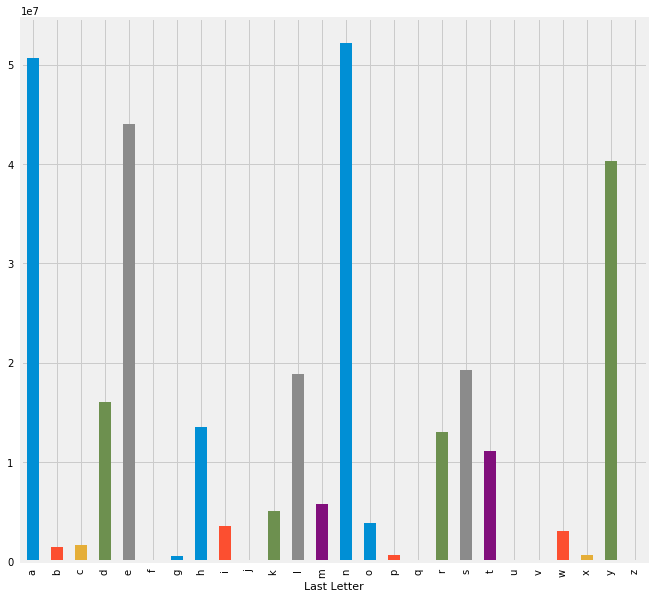

```python
last_letter_totals.plot.bar(figsize=(10, 10))
```

## Breakdown by Birth Sex

We can use the `pivot` operation to break the last letter of each name down by the birth sex:

```python
last_letter_pivot = baby_names.pivot_table(
    values='Count', # the field(s) to processed in each group
    index='Last Letter', # the rows (turned into index)
    columns='Sex', # the column values
    aggfunc=sum, # group operation
)
last_letter_pivot.head()
```

| Sex Last Letter | F | M |
| --- | --- | --- |
| a | 49128453 | 1585024 |
| b | 9666 | 1369244 |
| c | 18211 | 1565621 |
| d | 564804 | 15423771 |
| e | 31212081 | 12778932 |

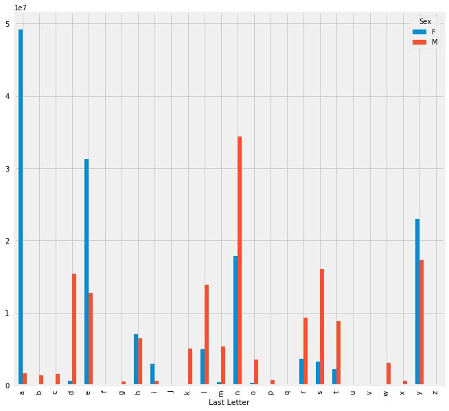

```python
last_letter_pivot.plot.bar(figsize=(10, 10));
```

These are the total counts. We might instead be interested in the proportion of males or females ending in each letter.

```python
prop_last_letter_pivot = last_letter_pivot.div(last_letter_totals, axis=0)
prop_last_letter_pivot
```

| Sex Last Letter | F | M |
| --- | --- | --- |
| a | 0.968746 | 0.031254 |
| b | 0.007010 | 0.992990 |
| c | 0.011498 | 0.988502 |
| d | 0.035325 | 0.964675 |
| e | 0.709510 | 0.290490 |
| f | 0.003193 | 0.996807 |
| g | 0.024381 | 0.975619 |
| h | 0.521534 | 0.478466 |
| i | 0.830335 | 0.169665 |
| j | 0.068372 | 0.931628 |
| k | 0.002880 | 0.997120 |
| l | 0.263349 | 0.736651 |
| m | 0.063177 | 0.936823 |
| n | 0.341749 | 0.658251 |
| o | 0.079855 | 0.920145 |
| p | 0.000955 | 0.999045 |
| q | 0.016123 | 0.983877 |
| r | 0.281733 | 0.718267 |
| s | 0.166683 | 0.833317 |
| t | 0.198072 | 0.801928 |
| u | 0.484623 | 0.515377 |
| v | 0.085827 | 0.914173 |
| w | 0.013170 | 0.986830 |
| x | 0.030559 | 0.969441 |
| y | 0.571341 | 0.428659 |
| z | 0.645210 | 0.354790 |

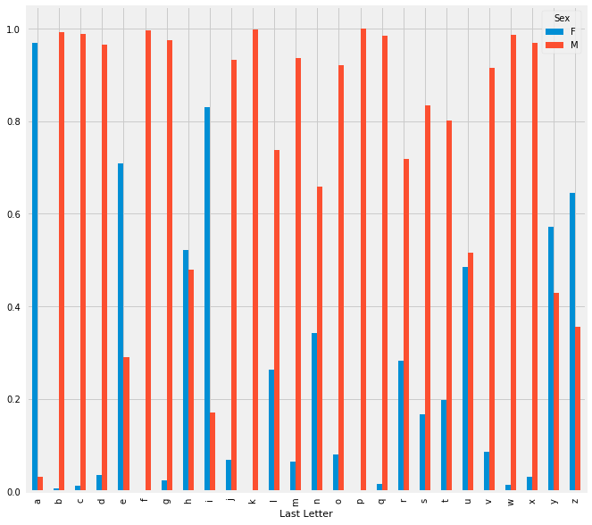

```python
prop_last_letter_pivot.plot.bar(figsize=(10, 10))
```

If we display the bars in order of the proportion of males we get a much clearer picture:

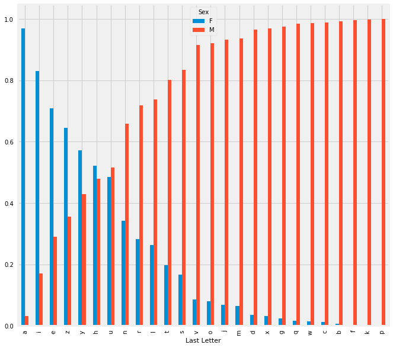

```python
(
    prop_last_letter_pivot
        .sort_values("M")
        .plot.bar(figsize=(10, 10))
)
```